# Лабораторная работа №11

Настройка безопасного удалённого доступа по протоколу SSH

Устинова В. В.

Российский университет дружбы народов, Москва, Россия

14 ноября 2026

# Информация

## Докладчик

- Устинова Виктория Вадимовна
- студент НПИбд-01-24
- Российский университет дружбы народов

# Вводная часть

## Цель работы

Приобретение практических навыков по настройке удалённого доступа к серверу с помощью SSH.

## Вход под пользователем root

С клиента выполнена попытка входа по SSH под пользователем root. После ввода пароля сервер отвечает Permission denied и завершает соединение.

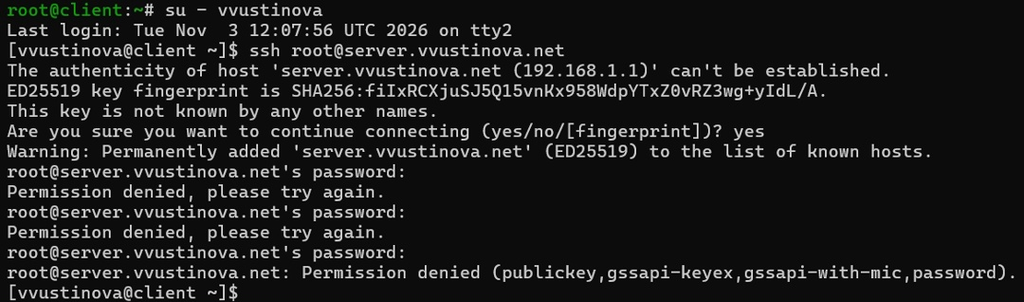

Попытка входа на сервер по SSH под пользователем root

## Запрет входа root

На сервере задан пароль root, в конфигурацию sshd добавлена строка `PermitRootLogin no`. Файл проверен командой `sshd -t`, sshd перезапущен.

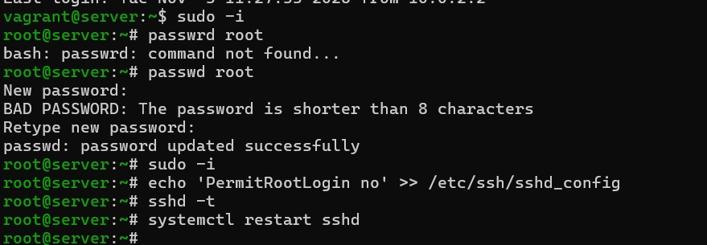

Запрет входа root по SSH в конфигурации sshd

## Вход пользователя до ограничений

Вход под своим пользователем выполнен с третьей попытки (первые два пароля введены неверно), так как ограничений на пользователей ещё нет.

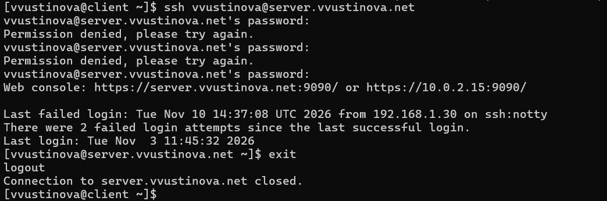

Вход под своим пользователем до ограничения списка пользователей

## Список AllowUsers

В конфигурацию sshd добавлена строка `AllowUsers vagrant`, разрешающая вход только пользователю vagrant. Файл проверен, sshd перезапущен.

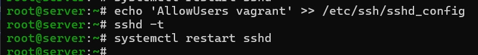

Добавление строки AllowUsers vagrant в конфигурацию sshd

## Отказ пользователю vvustinova

Попытка входа под пользователем vvustinova завершается отказом Permission denied, так как его нет в списке AllowUsers.

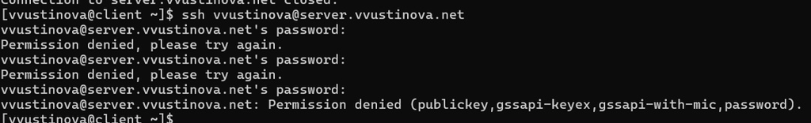

Отказ в доступе пользователю vvustinova после ограничения списка пользователей

## Добавление своего пользователя

Список разрешённых пользователей расширен: `AllowUsers vagrant vvustinova`. Результат проверен командой grep, sshd перезапущен.

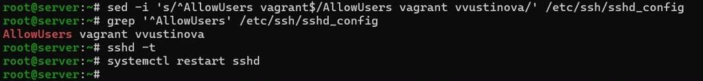

Добавление своего пользователя в список AllowUsers

## Успешный вход

После изменения списка AllowUsers вход под пользователем vvustinova выполнен успешно.

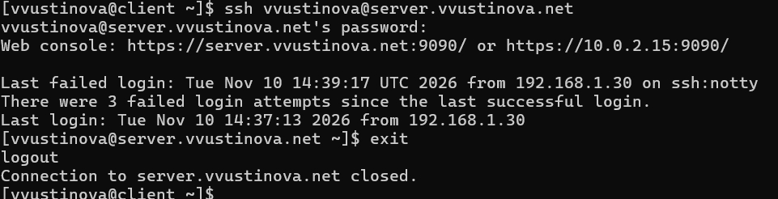

Успешный вход пользователя vvustinova после изменения списка AllowUsers

## Порт 2022 и ошибка привязки

В конфигурацию добавлены строки `Port 22` и `Port 2022`. После перезапуска служба активна, но в журнале видна ошибка привязки к порту 2022: для него в SELinux не задана метка SSH.

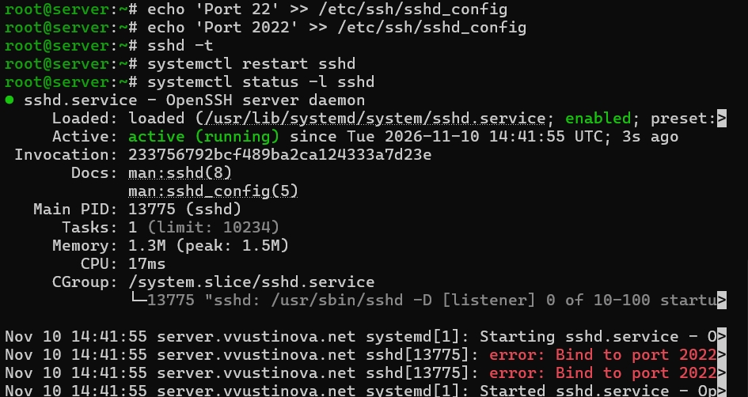

Добавление порта 2022 и ошибка привязки sshd к порту

## SELinux и межсетевой экран

Для порта 2022 задана метка ssh_port_t в SELinux, порт открыт в межсетевом экране (в текущей и постоянной конфигурации). После перезапуска sshd запускается без ошибок.

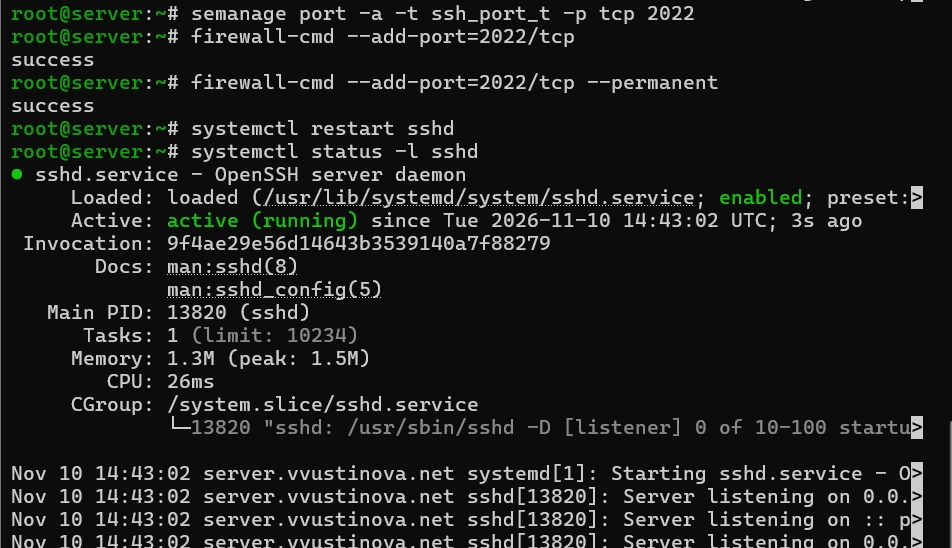

Настройка SELinux и межсетевого экрана для порта 2022

## Подключение через порты 22 и 2022

Выполнено подключение к серверу через порт по умолчанию и командой `ssh -p2022` через порт 2022. В обоих случаях вход выполнен, `sudo -i` даёт доступ root.

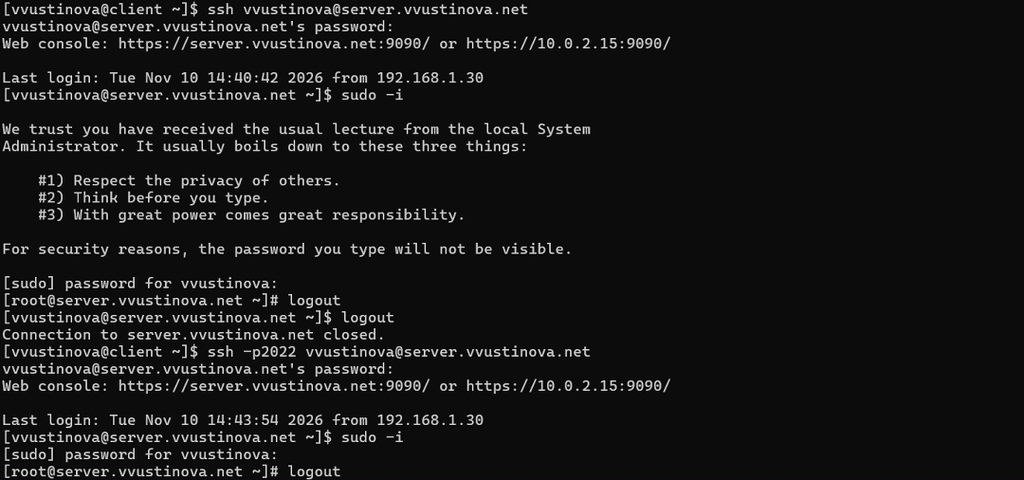

Подключение к серверу через порт 22 и через порт 2022

## Вход по ключу

На клиенте сформирована пара ключей SSH, открытый ключ скопирован на сервер командой `ssh-copy-id`. После этого вход выполняется без ввода пароля.

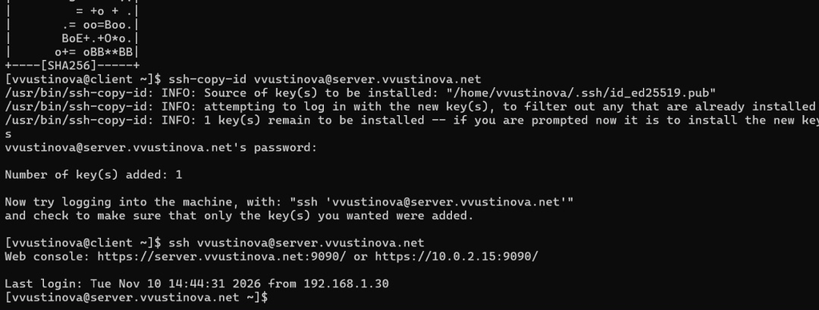

Копирование открытого ключа на сервер и вход по ключу

## SSH-туннель

Организован туннель с локального порта 8080 на порт 80 сервера. В выводе `lsof | grep TCP` виден процесс ssh, прослушивающий порт 8080 (webcache) по IPv4 и IPv6.

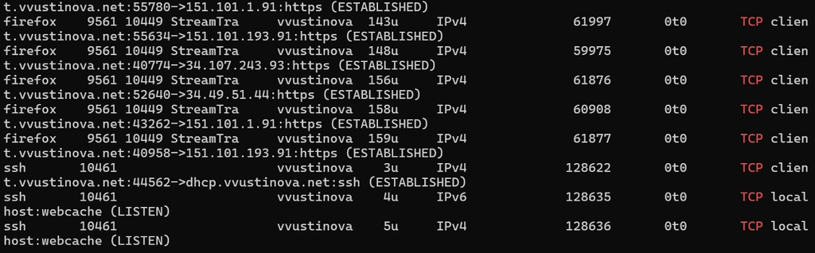

Вывод lsof после создания SSH-туннеля

## Проверка туннеля в браузере

В браузере по адресу localhost:8080 открывается страница с приветствием «Welcome to the server.vvustinova.net server.», туннель работает.

[figure not shown]

Страница сервера, открытая через SSH-туннель

## Команды на сервере через SSH

Выполнены команды на сервере: `hostname` показывает имя узла, `ls -Al` — список файлов домашнего каталога. Просмотрена почта: в ящике четыре сообщения, одно новое.

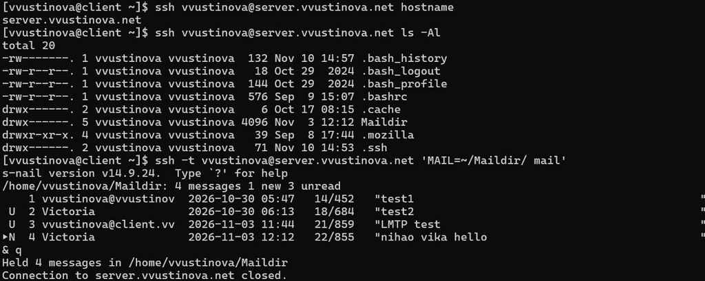

Выполнение команд на сервере через SSH

## X11Forwarding

В основном файле sshd_config параметр X11Forwarding отключён, в 50-redhat.conf включён. Добавлена строка `X11Forwarding yes` и запущена установка пакетов xorg-x11-xauth и firefox.

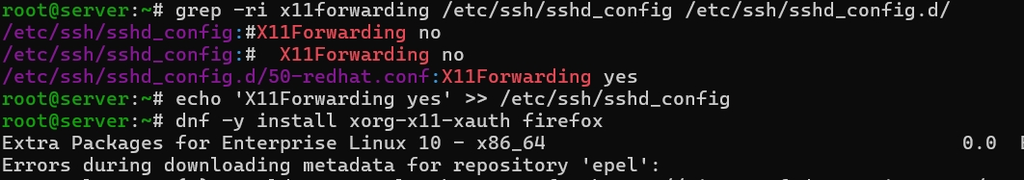

Разрешение X11Forwarding и установка пакетов для запуска Firefox

## Графическое приложение через SSH

Браузер Firefox, запущенный на сервере, отображается на клиенте.

[figure not shown]

Окно Firefox, запущенного на сервере и показанного на клиенте

## Скрипт ssh.sh

Скрипт копирует конфигурацию sshd, восстанавливает контексты SELinux, открывает порт 2022 в межсетевом экране, добавляет порт в SELinux и перезапускает sshd.

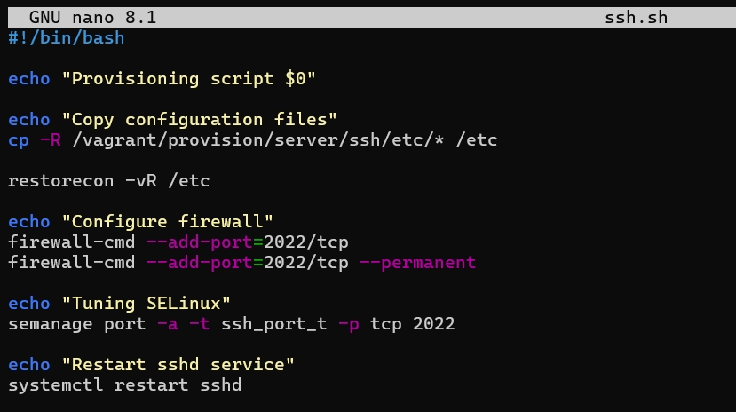

Скрипт ssh.sh виртуальной машины server

## Vagrantfile

В Vagrantfile в конфигурацию сервера добавлена запись provision «server ssh».

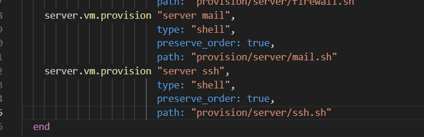

Запись server ssh в Vagrantfile

# Заключение

## Выводы

В ходе работы получены практические навыки по настройке удалённого доступа к серверу с помощью SSH. Запрещён вход root, доступ ограничен списком пользователей, настроена работа sshd через дополнительный порт 2022 с метками SELinux и правилами межсетевого экрана, а также вход по ключу. Создан SSH-туннель с локального порта 8080 на порт 80 сервера, через SSH выполнены команды и запущено графическое приложение. Действия по настройке сервера зафиксированы в скрипте `ssh.sh`, подключённом в Vagrantfile.